# GISPR Module 9 — Statistical Modeling, reticulate, and Spatial Web Services

Course: GIS Spatial Analysis with Python and R (GISPR)

# What you’ll accomplish this module

By the end of this notebook you’ll be able to:

| # | Learning outcome | Where |
| --- | --- | --- |
| 1 | Design an integrated workflow: apply statistical modeling / machine learning libraries (`scikit-learn`, `tidymodels`) in R and Python to a real spatial prediction problem, end to end | Sections 3–4 |
| 2 | Work across R and Python: transfer data and execute functions between R and Python within a single workflow using `reticulate` and Positron | Sections 1, 2, 3 |
| 3 | Pull live spatial data: access and integrate spatial data from web services — WMS/WFS, REST APIs, and near-real-time monitoring feeds — into an R/Python spatial workflow | Section 2 |

**NoteThis lab is optional extra credit**

From Module 8 on, the labs are **building blocks for your final project**. You’re strongly encouraged to work through this one, since the modeling, R/Python bridge, and web-service patterns here are the pieces most projects end up reusing. **Submitting the lab deliverables is optional** and counts as **extra credit** toward your final grade (see the end of this document).

### The framing problem for tonight

> **Where should Washington, Oregon, and Idaho add their next 10 PM2.5 monitors?** The regulatory PM2.5 network is built for compliance. It’s dense around Seattle, Portland, and Boise and thin almost everywhere else. In 2024 EPA tightened the annual PM2.5 standard to 9.0 µg/m³, so the gaps now matter: some unmonitored valleys could be over the new standard without anyone knowing. You’ll pull every monitor’s current **annual PM2.5 design value** straight from EPA’s public ArcGIS feature service. Covariates come from USGS and Census services: elevation, population density, and distance to the nearest major road. You’ll fit a model and rank the unmonitored locations most likely to have high annual PM2.5.

Nothing here is new spatial theory: you’ve done spatial joins (Module 4), raster/vector integration (Modules 5–6 and 8), and mapping (Module 7). Module 9 adds three pieces to the pipeline. A *statistical model* becomes the “integrate” stage. A *language bridge* means you aren’t stuck with whatever library R or Python happens to have. And *live web services* replace the downloaded file as your data source.

### Before you start — install the R packages

Run this once in your R console before anything else (it only installs what’s missing):

```r
pkgs <- c("tidymodels", "spatialsample", "ranger", "tmap", "sf", "dplyr",
          "ggplot2", "httr2", "jsonlite", "leaflet", "reticulate")
install.packages(setdiff(pkgs, rownames(installed.packages())))
```

The first install of `tidymodels` pulls in many dependencies and can take several minutes. Use a current `reticulate` (1.47 or newer; run `install.packages("reticulate")` to update): older versions can’t convert pandas 3 DataFrames back to R. On the Python side you need `requests`, `pandas`, `numpy`, and `scikit-learn`, which should all already be in your cloned ArcGIS Pro Python environment. If `scikit-learn` is missing just do the usual `conda install -c conda-forge scikit-learn`.

### Before you start — confirm your R ↔︎ Python bridge

Run this chunk first. If it errors, fix it now — don’t wait for the Guided Lab.

**ImportantStudents: point `use_python()` at your cloned ArcGIS Pro environment**

The chunk below contains **my** Python path (`C:/Users/mwebe/miniconda3/envs/ArcGIS_Clone/python.exe`), which won’t exist on your computer. Before you run it, replace that path with the `python.exe` of **your own cloned ArcGIS Pro conda environment** (the clone you made in earlier modules, not ArcGIS Pro’s default environment, which is read-only). Every chunk in this document, R or Python, uses whichever Python you set here.

```r
library(reticulate)

# !!! STUDENTS: CHANGE THIS PATH !!!
# The path below is the instructor's machine. Replace it with the python.exe
# of YOUR cloned ArcGIS Pro environment (or any conda env that already has
# pandas, numpy, requests and scikit-learn). If you don't know it, run
# `where python` in the ArcGIS Pro Python Command Prompt, or look in
# C:/Users/<you>/AppData/Local/ESRI/conda/envs/<your-clone>/python.exe
suppressWarnings(reticulate::use_python("C:/Users/mwebe/miniconda3/envs/ArcGIS_Clone/python.exe"))

suppressWarnings(py_config())
```

```
python:         C:/Users/mwebe/miniconda3/envs/ArcGIS_Clone/python.exe
libpython:      C:/Users/mwebe/miniconda3/envs/ArcGIS_Clone/python313.dll
pythonhome:     C:/Users/mwebe/miniconda3/envs/ArcGIS_Clone
version:        3.13.13 | packaged by Anaconda, Inc. | (main, Apr 22 2026, 16:49:16) [MSC v.1938 64 bit (AMD64)]
Architecture:   64bit
numpy:          C:/Users/mwebe/miniconda3/envs/ArcGIS_Clone/Lib/site-packages/numpy
numpy_version:  2.3.5

NOTE: Python version was forced by use_python() function
```

```r
# Expect: a Python path + version printed above.
```

# Section 1 — The Bridge: How `reticulate` Actually Works

*(Concept Input, ~10 min of tonight’s live-coding segment)*

`reticulate` embeds a Python interpreter inside your R session. You aren’t switching between two programs — one process, two languages, objects passed back and forth by name.

## 1a — Four ways to use Python from R

| Method | What it does | When you’d use it |
| --- | --- | --- |
| `source_python("script.py")` | Runs a `.py` file, pulls its top-level functions/variables into R | You already have a Python module and just want to call its functions |
| `py_run_string("...")` | Runs a string of Python code in the shared session | A quick one-off Python snippet inside an R script |
| `repl_python()` | Drops you into an interactive Python prompt inside your R console; `exit` returns to R | Exploring interactively before you commit code to a chunk |
| Quarto `{python}` chunks (what this document uses) | Each chunk is Python, but shares the reticulate session with the R chunks around it | Writing a document where both languages appear as first-class code, not a side quest |

## 1b — Type conversion, the short version

[output not shown]

## 1c — Live coding: pass an object each direction

```r
library(reticulate)

# An R data.frame — nothing python-flavored about it yet
monitor_counts_r <- data.frame(
  state = c("Washington", "Oregon", "Idaho"),
  n_monitors = c(30L, 25L, 12L)   # illustrative counts; Section 2 pulls the real ones
)
monitor_counts_r
```

```
       state n_monitors
1 Washington         30
2     Oregon         25
3      Idaho         12
```

```python
# `r.monitor_counts_r` reaches back into the R chunk above — the data.frame
# arrives already converted to a pandas DataFrame, no export/import step.
import pandas as pd

monitor_counts_py = r.monitor_counts_r
monitor_counts_py["share"] = monitor_counts_py["n_monitors"] / monitor_counts_py["n_monitors"].sum()
monitor_counts_py
```

```
        state  n_monitors     share
0  Washington          30  0.447761
1      Oregon          25  0.373134
2       Idaho          12  0.179104
```

```r
# `py$monitor_counts_py` reaches forward into the Python chunk above —
# the pandas DataFrame arrives back as an R data.frame, edits and all.
monitor_counts_back <- py$monitor_counts_py
str(monitor_counts_back)
```

```
'data.frame':   3 obs. of  3 variables:
 $ state     : chr  "Washington" "Oregon" "Idaho"
 $ n_monitors: num  30 25 12
 $ share     : num  0.448 0.373 0.179
 - attr(*, "pandas.index")=RangeIndex(start=0, stop=3, step=1)
```

That round trip — R → Python → R, no files written, no kernel switched — is the entire objective in miniature. Everything else this module does is that same handoff applied to spatial data and a statistical model.

## 1d — When to reach for the bridge (and when not to)

| Reach for `reticulate` when… | Just pick one language when… |
| --- | --- |
| The library you need only exists in the other language (e.g. a specific `scikit-learn` estimator, or an R spatial-statistics package with no Python equivalent) | Both languages have a perfectly good option and switching buys you nothing |
| You want to compare two implementations of the same idea (tidymodels vs. scikit-learn) side by side in one document | The task is small enough that the bridge’s overhead isn’t worth explaining to whoever reads this next |
| You’re prototyping in Python but the rest of your team’s pipeline is R (or vice versa) | You’re handing this off to someone who only knows one of the two languages — don’t make them install both toolchains to read your code |

# Section 2 — Pulling Data From Web Services

*(Concept Input, remainder of the live-coding segment)*

Module 9’s objective names three request/response patterns. All three are live services in this lab:

| Pattern | What you get back | What this lab pulls |
| --- | --- | --- |
| **WMS** (Web Map Service) | A rendered image. You can look at it, but you can’t query or join it | MRLC **NLCD 2021 land cover**, displayed for context only (Step 2e) |
| **WFS** (Web Feature Service) | Features: geometries plus attributes, through a standard OGC request | USGS **Watershed Boundary Dataset** HU6 basins, which serve as airsheds for spatial CV (Step 2b) |
| **REST API** (ArcGIS FeatureServer / MapServer / ImageServer) | Features, tables, or pixel values, filtered on the server with `where` and geometry parameters | EPA **PM2.5 annual design values** (2a); Census **TIGERweb** tracts and primary roads (2c); USGS **3DEP** elevation via `getSamples` (2d) |
| **Near-real-time feed** (IoT / SensorThings-style) | Time-stamped observations from physical devices, refreshed hourly or faster | EPA **AirNow** hourly monitor layer (Extended Application, Option 2) |

## 2a — Live services, with a safety net

Real endpoints go down, change schemas, and rate-limit — bad properties for a notebook twenty people run at once. So every pull below does the same thing: **try the live service first, save a cached copy, and fall back to that copy if the service fails.** That’s the production pattern too. Production pipelines never assume an upstream service is up.

```r
library(sf)
library(dplyr)
library(httr2)

study_states <- c("Washington", "Oregon", "Idaho")
study_fips   <- c("53", "41", "16")
study_bbox   <- st_bbox(c(xmin = -124.9, ymin = 41.9, xmax = -111.0, ymax = 49.1),
                        crs = st_crs(4326))

# CONUS Albers Equal Area (meters). Module 3's WA State Plane (EPSG:2926)
# doesn't cover a three-state study area, so we switch to a CRS that does.
target_crs <- 5070
grid_km    <- 50      # prediction grid cell size
min_gap_km <- 25      # a cell this close to an existing monitor counts as "monitored"

USE_CACHE  <- TRUE    # FALSE = live first, cache only as fallback; TRUE = read cache if present
cache_dir  <- "data/module9_cache"
dir.create(cache_dir, recursive = TRUE, showWarnings = FALSE)
dir.create("output", showWarnings = FALSE)
cache_gpkg <- file.path(cache_dir, "module9_cache.gpkg")

# Generic "live pull, or fall back to cache" wrapper for sf layers
pull_or_cache <- function(layer_name, pull_fn) {
  cached <- file.exists(cache_gpkg) && layer_name %in% st_layers(cache_gpkg)$name
  if (USE_CACHE && cached) return(st_read(cache_gpkg, layer = layer_name, quiet = TRUE))
  out <- tryCatch(pull_fn(), error = function(e) {
    message("Live pull for '", layer_name, "' failed: ", conditionMessage(e)); NULL
  })
  if (is.null(out) || nrow(out) == 0) {
    if (cached) {
      message("  -> using cached copy of '", layer_name, "'")
      return(st_read(cache_gpkg, layer = layer_name, quiet = TRUE))
    }
    stop("No live data and no cached copy for '", layer_name, "'.")
  }
  st_write(out, cache_gpkg, layer = layer_name, delete_layer = TRUE, quiet = TRUE)
  out
}

# A ~20-line R version of what arcgislayers::arc_select() does for you:
# page through an ArcGIS REST /query endpoint, check exceededTransferLimit,
# bind the pages into one sf object. Used in Steps 2b and 2c.
arc_query_sf <- function(layer_url, ..., page_size = 2000, max_pages = 50) {
  pages <- list()
  for (i in seq_len(max_pages)) {
    txt <- request(paste0(layer_url, "/query")) |>
      req_url_query(..., outSR = 4326, f = "json",
                    resultOffset = (i - 1) * page_size,
                    resultRecordCount = page_size) |>
      req_timeout(180) |>
      req_retry(max_tries = 3) |>
      req_perform() |>
      resp_body_string()
    if (grepl('^\\s*\\{\\s*"error"', txt)) stop("ArcGIS error: ", substr(txt, 1, 300))
    pages[[i]] <- read_sf(txt, quiet = TRUE)              # GDAL's ESRIJSON driver
    if (!grepl('"exceededTransferLimit"\\s*:\\s*true', txt)) break
  }
  bind_rows(pages)
}
```

### Step 2a — The monitoring network: EPA PM2.5 design values (ArcGIS REST, Python)

EPA publishes design values for every criteria pollutant as a public ArcGIS feature service. A **design value** is the statistic compared against the standard; for annual PM2.5 it’s a 3-year average of annual means. Layer `4` is *PM2.5 Annual*. You query it the way ArcGIS Pro does behind the scenes: an HTTP `GET` to `/query` with a `where` clause.

```python
# [Python] Step 2a — query EPA's Air Quality Design Values FeatureServer
import os
import time
import json
import requests
import numpy as np
import pandas as pd

DV_LAYER = ("https://services.arcgis.com/cJ9YHowT8TU7DUyn/ArcGIS/rest/services/"
            "Air_Quality_Design_Values_for_Criteria_Pollutants/FeatureServer/4")

def arcgis_query(layer_url, where="1=1", out_fields="*", page_size=1000, **extra):
    """Page through an ArcGIS REST /query endpoint and return attribute dicts.

    This is what ArcGIS Pro, the ArcGIS API for Python, and R's arcgislayers
    all do under the hood: request a page, check exceededTransferLimit,
    request the next page."""
    rows, offset = [], 0
    while True:
        params = {"where": where, "outFields": out_fields, "returnGeometry": "false",
                  "resultOffset": offset, "resultRecordCount": page_size, "f": "json", **extra}
        resp = requests.get(f"{layer_url}/query", params=params, timeout=60)
        resp.raise_for_status()
        payload = resp.json()
        if "error" in payload:        # ArcGIS reports errors inside an HTTP 200 response
            raise RuntimeError(payload["error"])
        batch = payload.get("features", [])
        rows.extend(f["attributes"] for f in batch)
        if not batch or not payload.get("exceededTransferLimit"):
            break
        offset += len(batch)
    return rows

USE_CACHE = r.USE_CACHE
dv_cache = os.path.join(r.cache_dir, "pm25_design_values.csv")
where = "state_name IN ({})".format(",".join(f"'{s}'" for s in r.study_states))
fields = ("AQSID,local_site_name,state_name,county_name,latitude,longitude,"
          "dv_year,design_value,dv_validity_ind,edt_id")

try:
    if USE_CACHE and os.path.exists(dv_cache):
        raise RuntimeError("USE_CACHE is TRUE")
    dv_raw = pd.DataFrame(arcgis_query(DV_LAYER, where=where, out_fields=fields))
    dv_raw.to_csv(dv_cache, index=False)
    source = "live EPA FeatureServer"
except Exception as e:
    if USE_CACHE and os.path.exists(dv_cache):
        print("USE_CACHE = TRUE: reading the saved copy instead of calling the live service.")
    else:
        print("Live pull failed (", e, "); falling back to the saved copy.")
    dv_raw = pd.read_csv(dv_cache)
    source = "cached copy"
```

```
USE_CACHE = TRUE: reading the saved copy instead of calling the live service.
```

```python
print(f"{len(dv_raw)} design-value rows from {source}")
```

```
446 design-value rows from cached copy
```

```python
dv_raw.head()
```

```
       AQSID        local_site_name  ... dv_validity_ind edt_id
0  160010010  Meridian - St. Luke's  ...               N      5
1  160010010  Meridian - St. Luke's  ...               Y      5
2  160010010  Meridian - St. Luke's  ...               Y      5
3  160010010  Meridian - St. Luke's  ...               Y      5
4  160010010  Meridian - St. Luke's  ...               Y      5

[5 rows x 10 columns]
```

The raw table can hold more than one row per site: several design-value periods, and sometimes a separate row with exceptional events (wildfire smoke, for example) excluded. Before modeling, reduce it to **one row per monitor for the latest period**:

```python
dv = dv_raw.copy()
dv["dv_year"] = pd.to_datetime(dv["dv_year"], unit="ms").dt.year   # ArcGIS dates are epoch milliseconds
latest = int(dv["dv_year"].max())
dv = dv[(dv["dv_year"] == latest) & dv["design_value"].notna()]

valid = dv["dv_validity_ind"].astype(str).str.upper().str.startswith("Y")
if valid.any():
    dv = dv[valid]
else:
    print("Note: no rows flagged valid; check dv_validity_ind values:",
          dv_raw["dv_validity_ind"].unique())

print("Exceptional-event variants present:", dict(dv["edt_id"].value_counts()))
```

```
Exceptional-event variants present: {5: np.int64(36)}
```

```python
dv = dv.sort_values("edt_id").drop_duplicates("AQSID")    # one consistent row per site

monitors_df = (dv.rename(columns={"longitude": "lon", "latitude": "lat",
                                  "design_value": "pm25_dv"})
                 [["AQSID", "local_site_name", "state_name", "lon", "lat", "pm25_dv"]]
                 .reset_index(drop=True))

print(f"{len(monitors_df)} monitors with a valid {latest - 2}–{latest} annual PM2.5 design value")
```

```
36 monitors with a valid 2023–2025 annual PM2.5 design value
```

```python
print(f"{(monitors_df.pm25_dv > 9.0).sum()} are above the 2024 NAAQS of 9.0 µg/m³")
```

```
0 are above the 2024 NAAQS of 9.0 µg/m³
```

```python
monitors_df.describe()
```

```
              AQSID         lon        lat    pm25_dv
count  3.600000e+01   36.000000  36.000000  36.000000
mean   4.323870e+08 -120.846269  45.793903   6.805556
std    1.242315e+08    2.866807   2.171550   1.439433
min    1.600900e+08 -123.348466  42.082222   4.400000
25%    4.103450e+08 -122.617559  43.969609   5.500000
50%    4.106700e+08 -122.314175  46.119156   6.800000
75%    5.304850e+08 -120.145217  47.574346   8.150000
max    5.307700e+08 -111.864167  48.760036   9.000000
```

### Step 2b — Airsheds from a WFS: USGS Watershed Boundary Dataset (R)

GDAL, and therefore `sf` and GeoPandas, speaks WFS natively, but only part of that works against this server:

| Request | Through GDAL (`st_layers()` / `st_read()`) | Result |
| --- | --- | --- |
| `GetCapabilities` (list the layers) | `st_layers("WFS:...")` | Works |
| `GetFeature`, no filter | `st_read("WFS:...", layer = ...)` | Works, but downloads every HU6 basin in the country, as curved `MultiSurface` geometries that break `st_intersects()` and `st_cast()` |
| `GetFeature` with a bbox | `st_read(..., wkt_filter = ...)` or GeoPandas `bbox=` | **HTTP 403**, whichever WFS version you force |

GDAL builds its own filtered `GetFeature` request, and this ArcGIS-hosted WFS rejects it. A hand-written WFS 2.0 request with the same bbox works. So the code below uses GDAL for `GetCapabilities` and writes the `GetFeature` URL itself. That’s a lesson in its own right: standards compliance varies by server, and sometimes you have to drop down a level to the raw request.

```r
# [R] Step 2b — HU6 basins from the USGS WBD WFS (REST fallback if WFS is down)
wbd_wfs  <- "https://hydro-wfs.nationalmap.gov/arcgis/services/wbd/MapServer/WFSServer"
wbd_rest <- "https://hydro.nationalmap.gov/arcgis/rest/services/wbd/MapServer/3"   # 6-digit HU

basins <- pull_or_cache("wbd_hu6", function() {
  out <- tryCatch({
    # GetCapabilities through GDAL: this part works
    lyrs <- st_layers(paste0("WFS:", wbd_wfs))$name
    message("WFS layers on offer: ", paste(lyrs, collapse = ", "))
    hu6  <- grep("Basin", lyrs, value = TRUE, ignore.case = TRUE)[1]   # HU6 = "Basin"
    if (is.na(hu6)) stop("couldn't find the HU6 (Basin) layer in GetCapabilities")

    # GetFeature by hand: GDAL's own bbox request gets HTTP 403 from this server.
    # WFS 2.0 + EPSG:4326 means lat/lon axis order: ymin,xmin,ymax,xmax
    bbox_latlon <- paste(c(study_bbox[["ymin"]], study_bbox[["xmin"]],
                           study_bbox[["ymax"]], study_bbox[["xmax"]]), collapse = ",")
    gml <- tempfile(fileext = ".gml")
    request(wbd_wfs) |>
      req_url_query(service = "WFS", version = "2.0.0", request = "GetFeature",
                    typeNames = hu6, count = 500,
                    bbox = paste0(bbox_latlon, ",urn:ogc:def:crs:EPSG::4326")) |>
      req_timeout(180) |>
      req_retry(max_tries = 3) |>
      req_perform(path = gml)

    # type = 6 forces MULTIPOLYGON, linearizing any curved MultiSurface geometry
    st_read(gml, type = 6, quiet = TRUE) |> st_make_valid()
  }, error = function(e) {
    message("WFS failed (", conditionMessage(e), "); trying the WBD REST endpoint")
    arc_query_sf(wbd_rest, where = "1=1", outFields = "huc6,name",
                 geometry = paste(study_bbox, collapse = ","),
                 geometryType = "esriGeometryEnvelope", inSR = 4326,
                 spatialRel = "esriSpatialRelIntersects", maxAllowableOffset = 0.01)
  })
  # WFS and REST spell field names differently (HUC6 vs huc6): lowercase the
  # attribute names, but leave the geometry column's name alone
  geom_col <- attr(out, "sf_column")
  nm <- names(out)
  nm[nm != geom_col] <- tolower(nm[nm != geom_col])
  names(out) <- nm
  select(out, any_of(c("huc6", "name")))
})

cat(nrow(basins), "HU6 basins intersect the study area\n")
```

```
36 HU6 basins intersect the study area
```

The REST fallback isn’t just a backup. The same USGS basins are also published as an ArcGIS REST layer, which filters on the server with no axis-order or geometry-type surprises. When a provider offers both, the REST route is usually the simpler one. WFS is still worth knowing, because many agencies publish *only* OGC services. Its successor, OGC API – Features, uses plain URLs and GeoJSON and avoids most of these quirks.

### Step 2c — Population density and roads from Census TIGERweb (ArcGIS REST, R)

TIGERweb is the Census Bureau’s ArcGIS Server. Its tract layer carries the 2020 census population (`POP100`) and land area (`AREALAND`), which gives you population density. Its *Primary Roads* layer gives you interstates and limited-access highways, which gives you distance-to-road. Both go through `arc_query_sf()`, the small paging helper defined in the setup chunk above.

```r
tiger <- "https://tigerweb.geo.census.gov/arcgis/rest/services/TIGERweb"

tracts <- pull_or_cache("tiger_tracts", function() {
  arc_query_sf(paste0(tiger, "/Tracts_Blocks/MapServer/10"),
               where = sprintf("STATE IN (%s)", paste0("'", study_fips, "'", collapse = ",")),
               outFields = "GEOID,STATE,POP100,AREALAND",
               maxAllowableOffset = 0.005,        # generalize on the server: ~500 m
               page_size = 4000)
})
stopifnot("POP100" %in% names(tracts))            # schema check — services do change

roads <- pull_or_cache("tiger_primary_roads", function() {
  arc_query_sf(paste0(tiger, "/Transportation_LargeScale/MapServer/0"),
               where = "1=1", outFields = "MTFCC",
               geometry = paste(study_bbox, collapse = ","),
               geometryType = "esriGeometryEnvelope", inSR = 4326,
               spatialRel = "esriSpatialRelIntersects",
               maxAllowableOffset = 0.002)
})

cat(nrow(tracts), "census tracts;", nrow(roads), "primary-road segments\n")
```

```
3241 census tracts; 638 primary-road segments
```

Now build the **prediction grid**: 50 km cells covering the three states, each with a population density (from the tract under its center) and a distance to the nearest primary road.

```r
tracts_p <- tracts |>
  st_transform(target_crs) |>
  mutate(pop_density = as.numeric(POP100) / pmax(as.numeric(AREALAND) / 1e6, 0.01)) |>  # people / km²
  select(pop_density)

roads_p <- st_transform(roads, target_crs)

grid_geom <- st_make_grid(tracts_p, cellsize = grid_km * 1000, what = "polygons")
grid      <- st_sf(cell_id = seq_along(grid_geom), geometry = grid_geom)

grid_ctr <- grid |>
  st_centroid() |>
  st_join(tracts_p, join = st_intersects, left = FALSE) |>   # drops cells outside WA/OR/ID
  distinct(cell_id, .keep_all = TRUE)
nearest <- st_nearest_feature(grid_ctr, roads_p)
grid_ctr$dist_road_km <- as.numeric(st_distance(grid_ctr, roads_p[nearest, ], by_element = TRUE)) / 1000

grid <- grid |> filter(cell_id %in% grid_ctr$cell_id)

# Hand the cell centers to Python as plain lon/lat — sf doesn't cross the bridge
grid_ll    <- st_coordinates(st_transform(grid_ctr, 4326))
grid_pts_r <- data.frame(cell_id = grid_ctr$cell_id, lon = grid_ll[, 1], lat = grid_ll[, 2])

cat(nrow(grid), "grid cells inside the study area\n")
```

```
261 grid cells inside the study area
```

### Step 2d — Elevation from the 3DEP ImageServer (ArcGIS REST, Python)

An ImageServer serves pixels, not features. Its `getSamples` operation returns the raster value at a set of points you send it, so you never download a DEM. This step samples the monitors from Step 2a *and* the grid cells that R just built, and the grid arrives here as `r.grid_pts_r`.

```python
# [Python] Step 2d — sample USGS 3DEP elevation at monitors + grid cell centers
ELEV = ("https://elevation.nationalmap.gov/arcgis/rest/services/"
        "3DEPElevation/ImageServer/getSamples")

def sample_3dep(lon, lat, chunk=25, tries=5):
    """Return elevation (m) at each lon/lat via 3DEP getSamples, in input order."""
    lon, lat = np.asarray(lon, float), np.asarray(lat, float)
    out = np.full(len(lon), np.nan)
    for start in range(0, len(lon), chunk):
        pts = [[x, y] for x, y in zip(lon[start:start + chunk], lat[start:start + chunk])]
        for attempt in range(tries):                  # the service intermittently returns 502/504
            resp = requests.post(ELEV, data={
                "geometry": json.dumps({"points": pts, "spatialReference": {"wkid": 4326}}),
                "geometryType": "esriGeometryMultipoint",
                "returnFirstValueOnly": "true",
                "f": "json"}, timeout=120)
            if resp.status_code < 500:
                break
            time.sleep(2 ** attempt)
        resp.raise_for_status()
        samples = resp.json().get("samples", [])
        ids = [s["locationId"] for s in samples]
        base = 0 if 0 in ids else 1                   # locationId is 0- or 1-based depending on server
        for s in samples:
            try:
                out[start + s["locationId"] - base] = float(s["value"])
            except (ValueError, TypeError, IndexError):
                pass                                  # "NoData" stays NaN
    return out

grid_pts = r.grid_pts_r
elev_cache = os.path.join(r.cache_dir, f"elevation_{int(r.grid_km)}km.csv")
try:
    if USE_CACHE and os.path.exists(elev_cache):
        raise RuntimeError("USE_CACHE is TRUE")
    monitors_df["elevation_m"] = sample_3dep(monitors_df.lon, monitors_df.lat)
    grid_pts["elevation_m"]    = sample_3dep(grid_pts.lon, grid_pts.lat)
    pd.concat([
        monitors_df.assign(kind="monitor", key=monitors_df.AQSID.astype(str))[["kind", "key", "elevation_m"]],
        grid_pts.assign(kind="grid", key=grid_pts.cell_id.astype(int).astype(str))[["kind", "key", "elevation_m"]],
    ]).to_csv(elev_cache, index=False)
except Exception as e:
    if USE_CACHE and os.path.exists(elev_cache):
        print("USE_CACHE = TRUE: reading saved elevations instead of calling the live service.")
    else:
        print("Live elevation pull failed (", e, "); falling back to the saved copy.")
    cache = pd.read_csv(elev_cache, dtype={"key": str})
    look = dict(zip(cache.kind + ":" + cache.key, cache.elevation_m))
    monitors_df["elevation_m"] = pd.to_numeric(
        [look.get(f"monitor:{k}") for k in monitors_df.AQSID.astype(str)], errors="coerce")
    grid_pts["elevation_m"] = pd.to_numeric(
        [look.get(f"grid:{int(k)}") for k in grid_pts.cell_id], errors="coerce")
```

```
USE_CACHE = TRUE: reading saved elevations instead of calling the live service.
```

```python
print("Monitors missing elevation:", int(monitors_df.elevation_m.isna().sum()))
```

```
Monitors missing elevation: 0
```

```python
print("Grid cells missing elevation:", int(grid_pts.elevation_m.isna().sum()))
```

```
Grid cells missing elevation: 0
```

### Step 2e — The WMS contrast: NLCD land cover as a picture (R)

You can **see** land cover through MRLC’s WMS. Try getting a number out of it. Every request returns PNG tiles, which are pixels colored for display. To *model* with NLCD you’d need a WCS or ImageServer, a Cloud-Optimized GeoTIFF (Module 10), or a download. That’s the WMS trap from tonight’s slides.

```r
library(leaflet)

mon <- py$monitors_df

leaflet() |>
  # Esri's light-gray basemap needs no API key (CartoDB's tiles can show a key warning)
  addProviderTiles("Esri.WorldGrayCanvas") |>
  addWMSTiles(
    "https://www.mrlc.gov/geoserver/mrlc_display/NLCD_2021_Land_Cover_L48/wms",
    layers  = "NLCD_2021_Land_Cover_L48",
    options = WMSTileOptions(format = "image/png", transparent = TRUE, opacity = 0.55),
    attribution = "MRLC NLCD 2021 (WMS)"
  ) |>
  addCircleMarkers(data = mon, lng = ~lon, lat = ~lat, radius = 5,
                   color = "#4b2e83", fillOpacity = 0.9, stroke = FALSE,
                   label = ~sprintf("%s: %.1f µg/m³", local_site_name, pm25_dv)) |>
  fitBounds(-124.9, 41.9, -111.0, 49.1)
```

[interactive chart not shown]

```r
# If the land-cover tiles come back blank, MRLC has renamed the layer: open
# .../wms?service=WMS&request=GetCapabilities and copy the layer's <Name>.
```

## 2f — SensorThings and the IoT piece of the objective

Design values are a slow-moving, 3-year statistic. That’s exactly why they work as a modeling target. A real-time platform answers a different question, such as *“what is PM2.5 at this monitor right now, and over the last 24 hours?”* OGC’s **SensorThings API** (named in this module’s required reading) standardizes that. Each device is a `Thing` with `Datastreams` of time-stamped `Observations`. EPA’s **AirNow** hourly feature layer is the same idea published as an ArcGIS layer, and Extended Application Option 2 uses it. Learn the vocabulary (`Thing`, `Datastream`, `Observation`). The modeling in this lab sticks to the stable annual statistic on purpose.

# Section 3 — Guided Lab: Build the PM2.5 Gap Model

*(Guided Lab, ~50–60 min)*

**Goal:** a `predict_exposure()` pipeline that takes the monitors and covariates from Section 2, fits a spatial model, and ranks the unmonitored grid cells with the highest predicted annual PM2.5. That ranking is the shortlist for the next 10 monitors.

## Step 1 — Spatial join: attach covariates to each monitor

```r
# [R] Step 1 — monitors (from Python) + tract density + road distance + basin
monitors_sf <- st_as_sf(py$monitors_df, coords = c("lon", "lat"), crs = 4326) |>
  st_transform(target_crs) |>                        # match the covariates' CRS before joining
  st_join(tracts_p, join = st_intersects) |>
  distinct(AQSID, .keep_all = TRUE) |>
  st_join(st_transform(basins, target_crs) |> select(huc6), join = st_intersects) |>
  distinct(AQSID, .keep_all = TRUE)

nearest_m <- st_nearest_feature(monitors_sf, roads_p)
monitors_sf$dist_road_km <- as.numeric(
  st_distance(monitors_sf, roads_p[nearest_m, ], by_element = TRUE)) / 1000

monitors_sf <- monitors_sf |>
  mutate(log_pop_density = log10(pop_density + 1),
         huc6 = coalesce(as.character(huc6), "unknown"))

cat("Monitors with a complete covariate set:",
    sum(complete.cases(st_drop_geometry(monitors_sf)[, c("pm25_dv", "log_pop_density",
                                                          "dist_road_km", "elevation_m")])),
    "of", nrow(monitors_sf), "\n")
```

```
Monitors with a complete covariate set: 33 of 36
```

```r
head(st_drop_geometry(monitors_sf))
```

```
      AQSID       local_site_name state_name pm25_dv elevation_m pop_density
1 160090010            St. Maries      Idaho     8.4  660.164001    4.401846
2 530730019 Bellingham-Pacific St Washington     5.2   24.112762 2174.705217
3 530770009      YAKIMA - 4TH AVE Washington     8.1  324.845184 2455.623018
4 530110024 Vancouver-NE 84th Ave Washington     5.5   64.400223 1411.356182
5 530330030 Seattle-10th & Weller Washington     7.1   42.205635 7147.710419
6 530330057    SEATTLE - DUWAMISH Washington     6.7    4.970766  381.562793
    huc6 dist_road_km log_pop_density
1 170103  30.07450124       0.7325422
2 171100   0.43549302       3.3376001
3 170300   2.35727929       3.3903385
4 170800   1.02205626       3.1499442
5 171100   0.06106415       3.8542277
6 171100   1.27808453       2.5827027
```

```r
# Save the modeling table (complete rows, no basin column) for the
# slide demos: Concept slides "Preparing Data" → "reticulate in Action" → "Fit → Predict"
monitors_sf |>
  select(AQSID, local_site_name, pm25_dv, log_pop_density, dist_road_km, elevation_m) |>
  filter(!is.na(pm25_dv), !is.na(log_pop_density), !is.na(dist_road_km), !is.na(elevation_m)) |>
  st_write(file.path(cache_dir, "monitors_covariates.gpkg"), delete_dsn = TRUE, quiet = TRUE)
```

## Step 2 — The naive-split trap (why this isn’t just `train_test_split()`)

Before fitting anything, notice that the monitors aren’t independent observations. Three Portland-area monitors breathe the same air (Tobler’s First Law again). Split them randomly and a test monitor usually has a training neighbor a few kilometers away. The model then “passes” by memorizing the neighbor instead of learning how population, roads, and terrain relate to PM2.5. Watch it happen:

```r
# [R] Step 2a — naive random cross-validation (the wrong way, done on purpose)
library(tidymodels)
monitors_cv <- monitors_sf |>
  filter(!is.na(pm25_dv), !is.na(log_pop_density), !is.na(dist_road_km), !is.na(elevation_m))

model_data <- monitors_cv |>
  st_drop_geometry() |>
  select(pm25_dv, log_pop_density, dist_road_km, elevation_m)

set.seed(9)
naive_folds <- vfold_cv(model_data, v = 5)

rf_spec <- rand_forest(trees = 500) |>
  set_engine("ranger") |>
  set_mode("regression")

rf_wf <- workflow() |>
  add_model(rf_spec) |>
  add_formula(pm25_dv ~ log_pop_density + dist_road_km + elevation_m)

naive_results <- fit_resamples(rf_wf, resamples = naive_folds,
                               metrics = metric_set(rmse))
naive_rmse <- collect_metrics(naive_results) |> filter(.metric == "rmse") |> pull(mean)
cat("Naive random 5-fold CV RMSE:", round(naive_rmse, 2), "µg/m³\n")
```

```
Naive random 5-fold CV RMSE: 1.33 µg/m³
```

```r
# [R] Step 2b — spatial block cross-validation (the fix)
library(spatialsample)

set.seed(9)
spatial_folds <- spatial_block_cv(monitors_cv, v = 5)

spatial_results <- fit_resamples(rf_wf, resamples = spatial_folds,
                                 metrics = metric_set(rmse))
spatial_rmse <- collect_metrics(spatial_results) |> filter(.metric == "rmse") |> pull(mean)
cat("Spatial block 5-fold CV RMSE:", round(spatial_rmse, 2), "µg/m³\n")
```

```
Spatial block 5-fold CV RMSE: 1.44 µg/m³
```

```r
cat("\nGap:", round(spatial_rmse - naive_rmse, 2),
    "µg/m³ higher error once nearby monitors can't leak into each other's fold.\n")
```

```
Gap: 0.1 µg/m³ higher error once nearby monitors can't leak into each other's fold.
```

```r
cat("That gap is the honest number: it's what you'd actually see predicting\n")
```

```
That gap is the honest number: it's what you'd actually see predicting
```

```r
cat("an unmonitored valley, which is the whole point of this exercise.\n")
```

```
an unmonitored valley, which is the whole point of this exercise.
```

With a few dozen real monitors the exact numbers will move with the seed, and with whatever EPA published most recently. The required `tidymodels` reading (geocompx’s spatial-ML post) shows the same naive-vs-spatial gap on a larger dataset (0.94 → 1.41 RMSE) if you want a more stable reference. Take away the *direction* of the gap, not its size. Spatial CV reports the more honest number, and it’s usually worse.

## Step 3 — Fit the model both ways: tidymodels *and* scikit-learn

This is where we see the handoff between languages pay off for this scenario. Fit the same random forest in R (`tidymodels`/`ranger`) and in Python (`scikit-learn`). Python gets a second kind of spatial CV: **grouping by HU6 basin**, the WFS layer from Step 2b. A whole airshed is held out at a time.

```r
# [R] Step 3a — final tidymodels fit on all monitors
final_rf_fit <- rf_wf |> fit(data = model_data)
final_rf_fit
```

```
══ Workflow [trained] ══════════════════════════════════════════════════════════
Preprocessor: Formula
Model: rand_forest()

── Preprocessor ────────────────────────────────────────────────────────────────
pm25_dv ~ log_pop_density + dist_road_km + elevation_m

── Model ───────────────────────────────────────────────────────────────────────
Ranger result

Call:
 ranger::ranger(x = maybe_data_frame(x), y = y, num.trees = 500,      num.threads = 1, verbose = FALSE, seed = sample.int(10^5,          1))

Type:                             Regression
Number of trees:                  500
Sample size:                      33
Number of independent variables:  3
Mtry:                             1
Target node size:                 5
Variable importance mode:         none
Splitrule:                        variance
OOB prediction error (MSE):       1.834658
R squared (OOB):                  0.1493905
```

```r
# Hand Python the same rows, plus the basin ID to group on
model_data_py <- monitors_cv |>
  st_drop_geometry() |>
  select(pm25_dv, log_pop_density, dist_road_km, elevation_m, huc6)
```

```python
# [Python] Step 3b — scikit-learn, with the data handed across the bridge
from sklearn.ensemble import RandomForestRegressor
from sklearn.model_selection import KFold, GroupKFold, cross_val_score

md = r.model_data_py
feats = ["log_pop_density", "dist_road_km", "elevation_m"]
X, y, groups = md[feats], md["pm25_dv"], md["huc6"]

rf_sklearn = RandomForestRegressor(n_estimators=500, random_state=9)

naive_cv = -cross_val_score(rf_sklearn, X, y, scoring="neg_root_mean_squared_error",
                            cv=KFold(n_splits=5, shuffle=True, random_state=9)).mean()

k = min(5, groups.nunique())                      # can't have more folds than basins
basin_cv = -cross_val_score(rf_sklearn, X, y, scoring="neg_root_mean_squared_error",
                            cv=GroupKFold(n_splits=k), groups=groups).mean()

rf_sklearn.fit(X, y)
```

```
RandomForestRegressor(n_estimators=500, random_state=9)
```

```python
print(f"scikit-learn RF on {len(X)} monitors across {groups.nunique()} HU6 basins")
```

```
scikit-learn RF on 33 monitors across 14 HU6 basins
```

```python
print(f"  naive KFold RMSE:              {naive_cv:.2f} µg/m³")
```

```
  naive KFold RMSE:              1.20 µg/m³
```

```python
print(f"  basin-grouped GroupKFold RMSE: {basin_cv:.2f} µg/m³")
```

```
  basin-grouped GroupKFold RMSE: 1.09 µg/m³
```

```python
print("Feature importances:", dict(zip(feats, rf_sklearn.feature_importances_.round(3))))
```

```
Feature importances: {'log_pop_density': np.float64(0.15), 'dist_road_km': np.float64(0.176), 'elevation_m': np.float64(0.674)}
```

Two implementations, one dataset, one document, and no exported CSVs or numbers copied between notebooks. Objectives 1 and 2 are both covered by these chunks.

## Step 4 — Predict across the grid and rank the shortlist

```r
# [R] Step 4 — predict every grid cell, then rank the ones far from any monitor
grid_cov <- grid_ctr |>
  st_drop_geometry() |>
  left_join(py$grid_pts[, c("cell_id", "elevation_m")], by = "cell_id") |>
  mutate(log_pop_density = log10(pop_density + 1)) |>
  filter(!is.na(elevation_m), !is.na(dist_road_km), !is.na(log_pop_density))

grid_cov$pred_pm25 <- predict(final_rf_fit, new_data = grid_cov)$.pred

predicted <- grid |> inner_join(grid_cov, by = "cell_id")

# "Unmonitored" = cell center more than min_gap_km from every existing monitor
gap_m <- apply(st_distance(st_centroid(predicted), monitors_sf), 1, min)
predicted$nearest_monitor_km <- as.numeric(gap_m) / 1000

candidates <- predicted |>
  filter(nearest_monitor_km > min_gap_km) |>
  arrange(desc(pred_pm25))

shortlist <- candidates |> slice_head(n = 10)

cat("Top 10 candidate cells for new PM2.5 monitors:\n")
```

```
Top 10 candidate cells for new PM2.5 monitors:
```

```r
print(st_drop_geometry(shortlist) |>
        transmute(cell_id, pred_pm25 = round(pred_pm25, 1),
                  nearest_monitor_km = round(nearest_monitor_km),
                  over_naaqs = pred_pm25 > 9.0))
```

```
   cell_id pred_pm25 nearest_monitor_km over_naaqs
1      402       8.5                 57      FALSE
2      404       8.5                 79      FALSE
3      170       8.5                 83      FALSE
4      193       8.3                 79      FALSE
5      383       8.3                 45      FALSE
6      215       8.3                 66      FALSE
7      378       8.3                 76      FALSE
8      403       8.3                 48      FALSE
9      269       8.2                 91      FALSE
10     358       8.2                 70      FALSE
```

## Step 5 — Map it

```r
# [R] Step 5 — predicted surface + basins + existing monitors + shortlist
library(tmap)
tmap_mode("plot")
```

```
ℹ tmap modes "plot" - "view"
```

```
ℹ toggle with `tmap::ttm()`
```

```
[plot mode] fit legend/component: Some legend items or map compoments do not
fit well, and are therefore rescaled.
ℹ Set the tmap option `component.autoscale = FALSE` to disable rescaling.
```

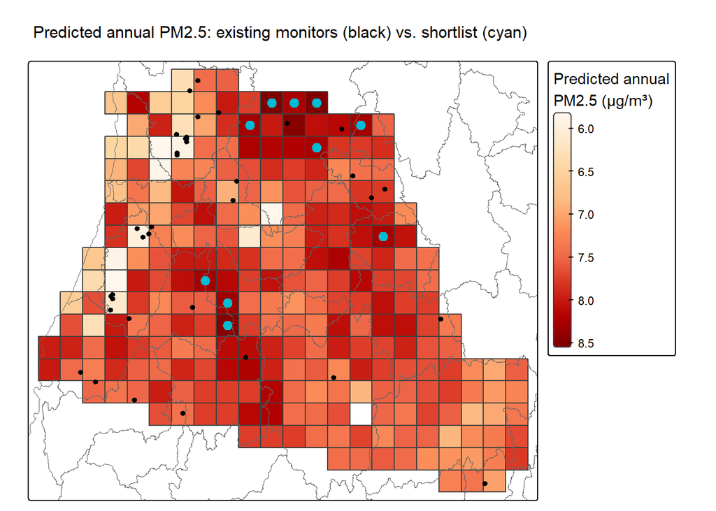

```r
tm_shape(predicted) +
  tm_polygons(fill = "pred_pm25",
              fill.scale = tm_scale_continuous(values = "brewer.or_rd"),
              fill.legend = tm_legend(title = "Predicted annual\nPM2.5 (µg/m³)")) +
  tm_shape(st_transform(basins, target_crs)) +
  tm_borders(col = "grey40", lwd = 0.5) +
  tm_shape(monitors_sf) +
  tm_dots(fill = "black", size = 0.3) +
  tm_shape(st_centroid(shortlist)) +
  tm_dots(fill = "#00bcd4", size = 0.6) +
  tm_title("Predicted annual PM2.5: existing monitors (black) vs. shortlist (cyan)")
```

### 🔧 Try it yourself

1. Wrap Steps 1–4 into a single `predict_exposure(monitors, grid, n_new)` function. Rerunning next year after EPA publishes new design values should then take one function call, not five chunks.
2. Add **longitude** as a fourth covariate (east vs. west of the Cascades). Does the spatial-CV RMSE improve, or does the naive RMSE improve more? What does that tell you?

```r
predict_exposure <- function(monitors_sf, grid_sf, n_new = 10) {
  # 1. join covariates, 2. spatial CV check, 3. fit, 4. predict + rank
  # — your implementation here, built from Steps 1–4 above
}
```

# ☕ Break (10–15 min)

# Section 4 — Extended Application

*(~40–50 min. Pick the option that matches what you want more practice on.)*

## Option 1 — Push the language bridge further

Refit Step 3’s model with a `scikit-learn` estimator you don’t have a comfortable `tidymodels` equivalent for, such as a gradient boosting regressor. Compare its basin-grouped CV RMSE to the random forest.

```python
# [Python] Option 1 — a different scikit-learn estimator, same grouped CV
from sklearn.ensemble import GradientBoostingRegressor

gbr = GradientBoostingRegressor(random_state=9)
-cross_val_score(gbr, X, y, scoring="neg_root_mean_squared_error",
                 cv=GroupKFold(n_splits=k), groups=groups).mean()
```

## Option 2 — Add the near-real-time feed

EPA publishes the **last 24 hours of AirNow monitor data** as a public ArcGIS feature service, refreshed hourly. Open it, find the PM2.5 field names yourself (don’t guess), and compare *tonight’s* readings to each monitor’s annual design value. Which monitors are running far above their annual level right now, and why might that be?

```r
# [R] Option 2 — inspect first, then query (arcgislayers or arc_query_sf both work)
airnow_url <- paste0("https://services.arcgis.com/cJ9YHowT8TU7DUyn/arcgis/rest/",
                     "services/Air_Now_Monitor_Data_Public/FeatureServer")
# library(arcgislayers); arc_open(airnow_url)   # lists the layers; open the PM2.5 one
# ...then arc_select(<layer>, where = "...", filter_geom = study_bbox)
```

## Option 3 — Bring your own reticulate bridge

If you have a Python function from your own work, `source_python()` it into this R session and use its output somewhere in the pipeline above. The point is to prove the bridge works on code you didn’t write for this course.

# 🔍 Module 9 — Self-Check Questions

Work through these without looking at the chunks above, then verify.

**The bridge**

1. Name the four ways to run Python from R that Section 1 covers. Which one does this document use, and why does that mean you never had to switch a kernel?
2. Inside a Python chunk, how do you reach an object created in the R chunk above it? How does it work in reverse?
3. `sf` objects don’t convert automatically across the bridge. What did Steps 2c and 2d pass across instead, and in which direction?

**Web services**

4. What’s the practical difference between what the NLCD WMS returned in Step 2e and what the WBD WFS returned in Step 2b? Which one could you feed into a spatial join? And why did Step 2b write its own `GetFeature` request instead of letting `st_read()` do it?
5. Steps 2a, 2c, and 2d all hit ArcGIS REST endpoints, but three different kinds (FeatureServer, MapServer, ImageServer). What did you get back from each, and which operation did you call?
6. What does `exceededTransferLimit` tell you, and what would happen to your monitor count if your code ignored it?

**Modeling and the naive-split trap**

7. Why did the naive 5-fold CV in Step 2a report a *better* (lower) RMSE than spatial block CV in Step 2b? Which number would hold up for an unmonitored valley?
8. What do `spatial_block_cv()` (R) and `GroupKFold` grouped by HU6 basin (Python) both guarantee that plain `vfold_cv()` / `KFold` don’t? Why are basins a reasonable grouping for *air* pollution?

**Putting it together**

9. Step 4 excludes cells within `min_gap_km` of an existing monitor before ranking. What would the top 10 look like without that filter, and why would that list be useless to a monitoring program?
10. Name one thing in Section 2 that can break with live services that never broke with synthetic data, and say how this lab handles it.

# ⭐ Optional Extra Credit — Lab Deliverables

You’re encouraged to complete this lab, ideally on your own project’s data, because each deliverable below is a building block you can reuse in your final project. **Submission is optional** and counts as **extra credit** toward your final grade.

### Extra Credit 1 — The Bridge, on Your Own Data

Pass an object of your choosing from R to Python (or Python to R) using `reticulate`, do something with it in the second language that would have been awkward or impossible in the first, and bring it back. Submit: the chunk(s), one paragraph on why you picked that direction across the bridge.

### Extra Credit 2 — Naive vs. Spatial Cross-Validation, Your Data or Ours

Using this lab’s monitors, or a spatial dataset of your own with at least 15–20 observations, reproduce Step 2’s comparison: a naive random CV RMSE and a spatial block CV RMSE for the same model. Submit: both numbers, the gap between them, and 2–3 sentences on whether the gap is big enough to change a real decision.

### Extra Credit 3 — One Web Service, Applied to Your Project

Find a public web service (REST, WFS, ImageServer, or OGC API) that serves data for your final project. Pull it with the try-live-then-cache pattern from Section 2a and run one technique from this lab on it. Submit: the chunk(s) and 2–3 sentences on whether it will stay in your final workflow.

**To submit (optional):** render this `.qmd` (or your own `.qmd`/`.ipynb`) to HTML and upload both to the Module 9 lab extra-credit assignment in Canvas. Tag your repo commit `module9-lab` if you’re using GitHub.

**Stuck?** Post in Ed Discussion — tag `#module9`. Include your error message, which chunk failed, and your OS/environment (Positron’s Console pane shows both the R and Python versions in use — paste that too). If a web-service chunk fails, include the URL it was calling. Half the time the fix is “the service was down; the cache fallback kicked in.”